# Determining Fitness For Coaching Decision Making

Author

Jack Robinson, Josh Ogilvie, Josh Pawliuk

Published

March 7, 2026

## What is Fitness

To determine which Runner is fitter, we must first define fitness. It may be easy to look at some run times and distances and try to determine who the better runner is, but this does not help us understand which runner is fitter. A common and very robust measurement for determining fitness is a VO2 max test, which assesses “the body’s ability to take in, transport, and use oxygen during exercise” (“Faculty of Kinesiology, Sport, and Recreation,” n.d.). This test is also costly and requires advanced instruments to achieve accurate results. In this analysis, we will be using an approach that allows us to analyze a runner’s fitness using data from Strava. Fitness level in this analysis will be determined by the impact that a runner’s heart rate has on their pace. This proxy for aerobic efficiency gives us an understanding of which runner has a more efficient exchange of oxygen, or who is fitter. Using the Strava data, the runners’ fitness levels can be evaluated by examining the relationship between their running pace and heart rate. A larger improvement in pace for the same increase in heart rate would indicate a greater level of aerobic fitness. In other words, the runner whose pace improves more for a given increase in heart rate can translate physiological effort into performance more effectively. We can use this metric to determine both who is currently more fit and also how much increase in fitness each runner has achieved over the timespan of the available data. In Figure 1, a side-by-side graph shows the average pace in seconds per km of both Collie and Hound. In Figure 2, a similar graph with a depiction of their average heart rate over time. These observations will be the foundation for our analysis and will be used to determine who the fitter runner is.

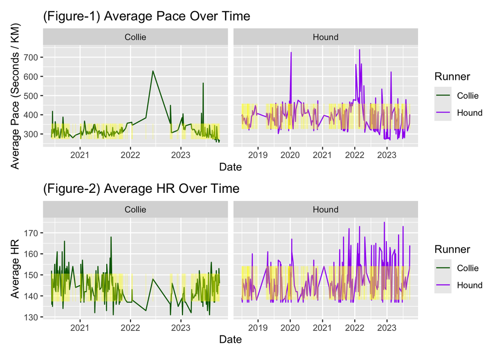

## Which Athlete Has Better Fitness

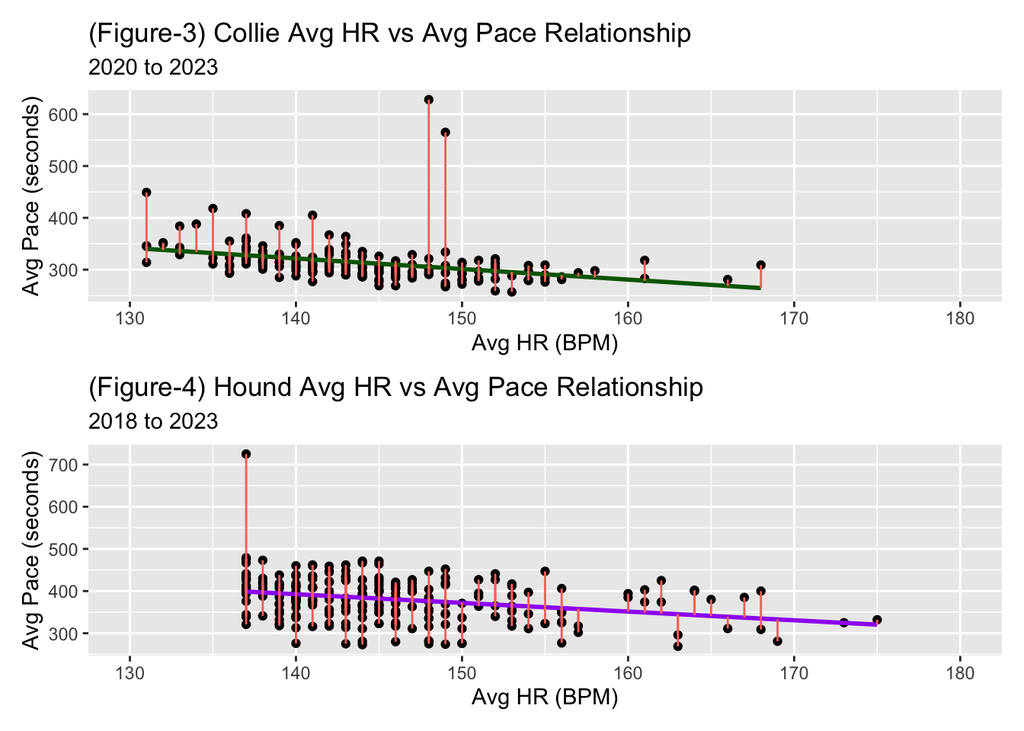

(Figure-5) Model Statistics - Collie

Regression of Average Pace on Heart Rate

|  | r.squared | Adj R-Squared | Residual SE | P-value |
| --- | --- | --- | --- | --- |
| Model | 0.1119218 | 0.1074 | 37.8420 | 0.0000 |

(Figure-6) Model Statistics - Hound

Regression of Average Pace on Heart Rate

|  | r.squared | Adj R-Squared | Residual SE | P-value |
| --- | --- | --- | --- | --- |
| Model | 0.08757697 | 0.0840 | 49.9464 | 0.0000 |

(Figure-7) Runners Fitness

Average Pace on Heart Rate

| Runner | Change in Pace | P-value | R-squared |
| --- | --- | --- | --- |
| Collie | −2.0431 | 0.0000 | 0.1119 |
| Hound | −2.0615 | 0.0000 | 0.0876 |

## Who improved their fitness more

(Figure-8) Runners Fitness Improvement

Change in Pace and Heart Rate Over Time

| Runner | Change in HR | P-value | R-squared | Change in Pace | P-value | R-squared |
| --- | --- | --- | --- | --- | --- | --- |
| Collie | −0.0041 | 0.0003 | 0.0707 | −0.0023 | 0.7408 | 0.0006 |
| Hound | 0.0028 | 0.0048 | 0.0535 | −0.0208 | 0.0005 | 0.0804 |

## Outdoor Running Performance

To determine Hound and Collie’s performance in outdoor runs we performed a seasonality analysis using average pace in seconds per kilometer recorded on a monthly basis for Collie in Figure-9 and Hound in Figure-10. We refined this data by taking the average of the data points in Figure-9 and Figure-10 to get a single data point for each month. We then performed a non-linear regression as seen in Figure-11 for Collie and Figure-12 for Hound. It is important to note that Hound had significantly more indoor runs that were removed when performing this seasonality analysis and after filtering, Collie only has one observation in December. When comparing Collie’s results in Figure-9 and Figure-11 and Hound’s results in Figure-10 and Figure-12 we observed a lower and more consistent average pace for Collie. This implies that outdoor running conditions on a month to month basis have less of an effect on Collie’s running performance than Hounds. Hounds’ average pace follows a seasonality pattern that implies a slower pace in the colder months and a faster pace in the warmer months. This could be attributed to temperature or outdoor running conditions affecting Hound’s pace. Hound’s February data includes two races in which Hound decreased their pace significantly which is most likely due to the run being in a competitive environment. When looking at Figure-9 it is apparent that Collie runs less in November and December than other months. As a coach we could encourage Collie to maintain their running volume year round to maintain consistency. Consistency is key as aerobic fitness can begin to decline in as little as 7-10 days (Barbieri A 2023). Overall, Collie’s current level of consistency is a positive from a coaching perspective as we know that outdoor conditions will have a limited affect on their running ability and effort and extending Collie’s consistency through all months of the year is more feasible than trying to build a new habit of consistency for Hound.

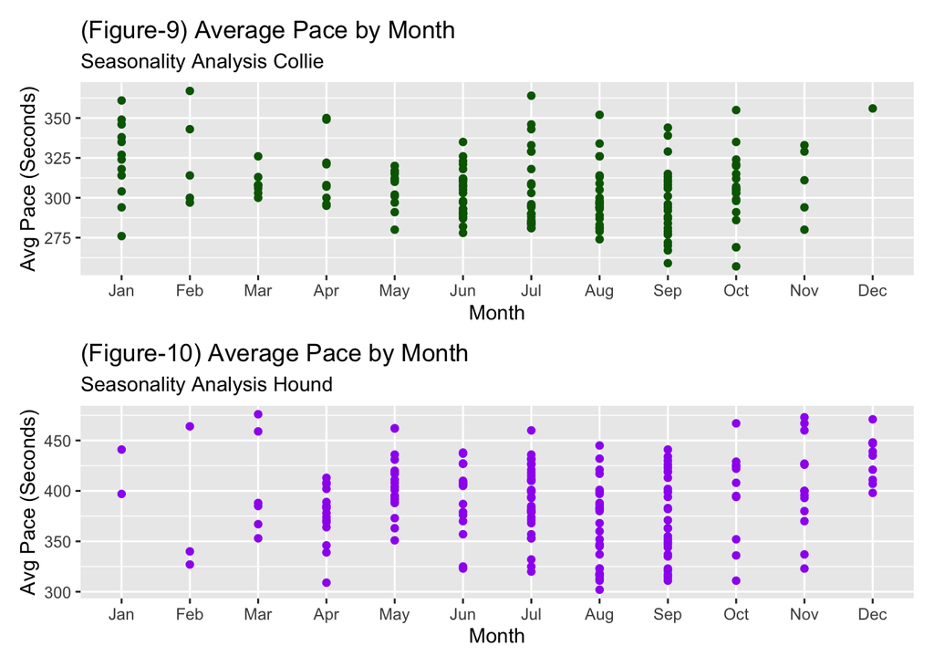

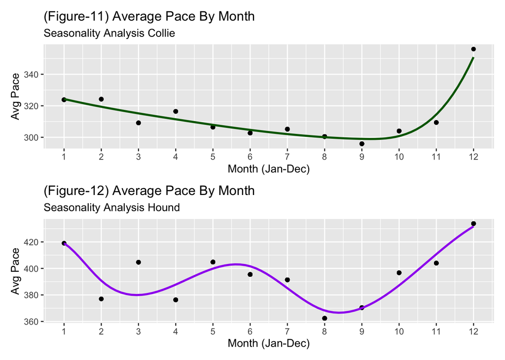

## Who is Better to Coach

One unique value we are exposed to with this data set is each runner’s Aerobic TE. This measurement is scored on a 0-5 scale and uses many individualized, along with run-specific variables, to determine how effective the run is on their fitness. In this analysis, we considered Aerobic TE to be a strong measure for understanding which runner exerts more effort. Running at a higher Aerobic TE is more difficult to maintain and requires discipline to overcome the strain that running has on an individual’s body. Figure 14 depicts a histogram of each runners Aerobic TE from their available runs. This data was filtering in the same way as we did when determining who is fitter, removing any observations that were seen to be not run specific. When coaching, having an athlete who is more dedicated to improvement and willing to exert maximum effort will typically see results that follow sooner. In the case of the coach, higher effort not only benefits the athletes’ improvement in running but can also help the coach understand if their techniques or trials are working by quantifying results faster, compared to coaching someone where improvement may be slower due to a lack of maximum effort. Figure 14 provides a depiction of which runner is exerting more effort more often, as well as a red line that indicates the mean Aerobic TE for each runner over all the analyzed runs. It is clear that Collie maintains higher Aerobic TE where they are observed running in the “Highly improving”(“Garmin Technology: Training Effect,” n.d.) area compared to Hound, who is generally seen to be running in the “improving” area. It is also important to note that Collie has many observations at an Aerobic TE of 5, which is considered “Overreaching” and can potentially be considered dangerous; however, coaching someone to exert less effort is much easier than convincing someone to exert more. In our evaluation of which runner to coach, we determined that Collie would be a better fit and will likely see a greater impact from additional support and professional guidance.

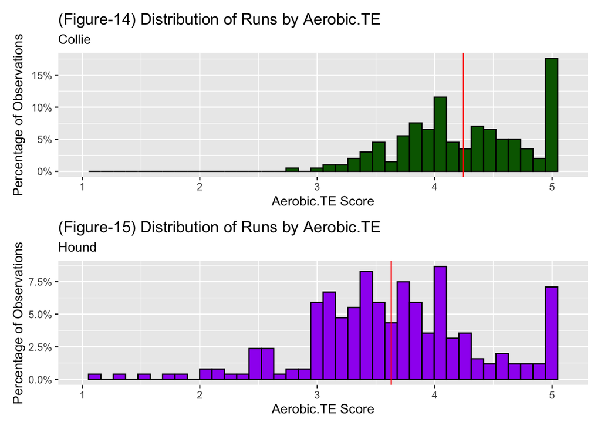

## References

“9.5 Including Uncited Items in the Bibliography.” n.d. https://pandoc.org/demo/example33/9.5-including-uncited-items-in-the-bibliography.html.

Barbieri A, Gallo G, Fuk A. 2023. “Cardiorespiratory and Metabolic Consequences of Detraining in Endurance Athletes.” *Frontiers in Physiology*. https://pmc.ncbi.nlm.nih.gov/articles/PMC10853933/.

“Faculty of Kinesiology, Sport, and Recreation.” n.d. https://www.ualberta.ca/en/kinesiology-sport-recreation/fitness-testing-services/sport-health-assessment-centre/packages.html.

Friel, Joe. 2024. “What Is Running Efficiency and How Is It Measured?” https://www.trainingpeaks.com/blog/the-efficiency-factor-in-running/.

“Garmin Technology: Training Effect.” n.d. https://www.garmin.com/en-CA/garmin-technology/running-science/physiological-measurements/training-effect/.

“GT.” n.d. https://gt.rstudio.com/.

“Reference Management with BibTeX, When Using r Markdown – a Short Guide.” n.d. https://bibtex.eu/rmarkdown/.